# Cap DAP Final Copy

Aubrey Ahern

12/14/2022

## Introduction

- I took my data from https://data.chhs.ca.gov/dataset/hiv-aids-cases.
- The data was collected from 2011-2017 within the state of California in order to collect public health information.
- The data outlines all cause deaths in HIV/AIDS by gender, age, race/ethnicity, and transmission category.
- I used this data to take a look at the distribution of HIV/AIDS cause deaths by different demographic variables, primarily looking at how good of a predictor gender is in determining health outcomes.
- While there is no biologic reasoning for why certain groups of people experience HIV/AIDS cause deaths at a higher rate, we can call upon public health knowledge to answer these questions.
  - When taking social determinants of health into consideration, we may see that women and LGBTQ+ communities experience lower accessibility to health care and are often subjected to discrimination within the health care field. This may provide an explanation to the data that will be presented throughout this project (Sharman).

#### Getting Started

- I made sure my data was compatible to work with R by…
  - Excluding spaces and special characters from column names
  - Organizing categories into columns instead of rows
  - Making sure that each cell contained only one piece of information.
- After importing my data, I made all variables factors, except for count which I made numeric.  
  #### Limitations
- While this data set contains a lot of information on demographic information on those who have died from HIV/AIDS, it only includes **one** piece of information per row, instead of multiple per datum. I have worked with the data as best I could but would potentially use a more extensive data set in the future.

## Analysis

### Test #1

- First, I created a data frane containing only the data I wanted.

```r
DF_gender <- DF %>%
  group_by(current_gender) %>%
  summarise(count = sum(count)) %>%
  arrange(desc(count)) %>%
  na.omit()

DF_gender
```

[output not shown]

- Next, let’s visualize this relationship.

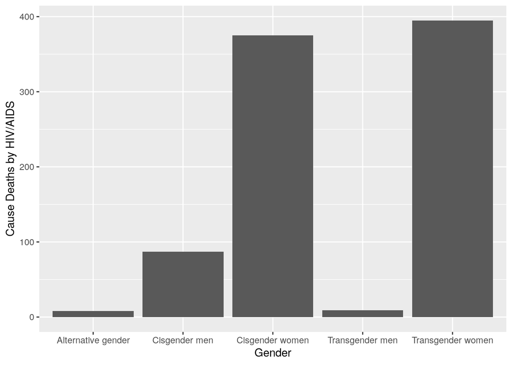

```r
ggplot(DF_gender, aes(current_gender, count))+
     geom_col()+
  labs(x = "Gender",
       y = "Cause Deaths by HIV/AIDS")
```

```r
DF_model <- DF %>%
  slice(106:140)
myMod1 <- aov(count ~ current_gender, data = DF_model)
TukeyHSD(myMod1, conf.level=.95)
```

```
##   Tukey multiple comparisons of means
##     95% family-wise confidence level
##
## Fit: aov(formula = count ~ current_gender, data = DF_model)
##
## $current_gender
##                                             diff        lwr        upr
## Cisgender men-Alternative gender      11.2857143  -1.044684  23.616112
## Cisgender women-Alternative gender    52.4285714  40.098173  64.758969
## Transgender men-Alternative gender     0.1428571 -12.187541  12.473255
## Transgender women-Alternative gender  55.2857143  42.955316  67.616112
## Cisgender women-Cisgender men         41.1428571  28.812459  53.473255
## Transgender men-Cisgender men        -11.1428571 -23.473255   1.187541
## Transgender women-Cisgender men       44.0000000  31.669602  56.330398
## Transgender men-Cisgender women      -52.2857143 -64.616112 -39.955316
## Transgender women-Cisgender women      2.8571429  -9.473255  15.187541
## Transgender women-Transgender men     55.1428571  42.812459  67.473255
##                                          p adj
## Cisgender men-Alternative gender     0.0854663
## Cisgender women-Alternative gender   0.0000000
## Transgender men-Alternative gender   0.9999997
## Transgender women-Alternative gender 0.0000000
## Cisgender women-Cisgender men        0.0000000
## Transgender men-Cisgender men        0.0917044
## Transgender women-Cisgender men      0.0000000
## Transgender men-Cisgender women      0.0000000
## Transgender women-Cisgender women    0.9609197
## Transgender women-Transgender men    0.0000000
```

- These results indicate the following conclusions: - There is no significant difference in the number of cause deaths by HIV/AIDS between cisgender men and alternative gender people. - **Cisgender women experience significantly more cause deaths by HIV/AIDS than alternative gender people.** - There is no significant difference in the number of cause deaths by HIV/AIDS between transgender men and alternative gender people. - **Transgender women experience significantly more cause deaths by HIV/AIDS than alternative gender people.** - **Cisgender women experience significantly more cause deaths by HIV/AIDS than cisgender men.** - There is no significant difference in the number of cause deaths by HIV/AIDS between transgender men and cisgender men. - **Transgender women experience significantly more cause deaths by HIV/AIDS than cisgender men.** - **Cisgender women experience significantly more cause deaths by HIV/AIDS than transgender men.** - There is no significant difference in the number of cause deaths by HIV/AIDS between transgender women and cisgender women. - **Transgender women experience significantly more cause deaths by HIV/AIDS than transgender men.**  
- Thus, both cisgender and transgender women experience significantly more cause deaths by HIV/AIDS than those of any other gender but do not experience significantly different rates of cause deaths by HIV/AIDS from one another and our null hypothesis may be rejected.

### Test #2

- Since we now know that trans and cis women experience more deaths by HIV-AIDS than those of other genders, let’s analyze the relationship between year and deaths for trans and cis women.
- I created a new data frame that only contains data for trans women.

```r
DF_transwomen <- DF %>%
  filter(current_gender == "Transgender women")%>%
  mutate(year = as.numeric(year),
         count = as.numeric(count))
DF_transwomen
```

- Then I visualized this new dataframe.

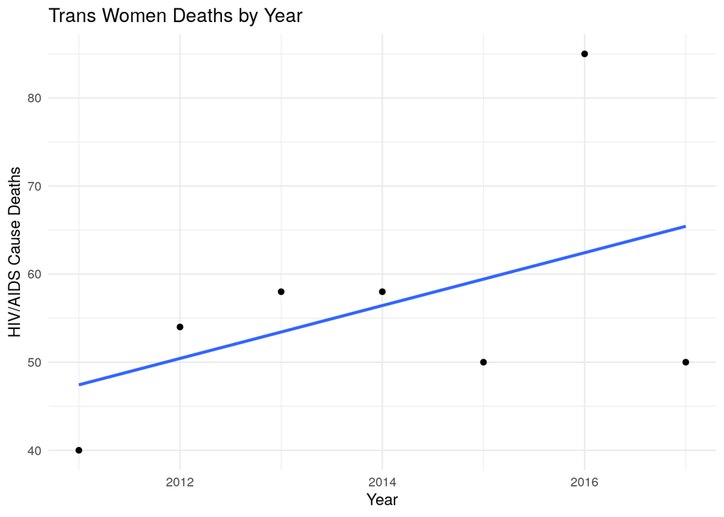

```r
ggplot(DF_transwomen, aes(x = year, y = count)) +
  geom_point() +
  geom_smooth(method = "lm", se = FALSE)+
  labs(x = "Year",
       y= "HIV/AIDS Cause Deaths",
       title = "Trans Women Deaths by Year") +
  theme_minimal()
```

- Then, I ran a t-test to see if there is a relationship between time (in years) and death count for trans women.
  - I chose to conduct a t-test rather than another ANOVA test as I considered year to be numeric data rather than categorical.

```r
myMod2 <- lm(count ~ year, data = DF_transwomen)
summary(myMod2)
```

```
##
## Call:
## lm(formula = count ~ year, data = DF_transwomen)
##
## Residuals:
##       1       2       3       4       5       6       7
##  -7.429   3.571   4.571   1.571  -9.429  22.571 -15.429
##
## Coefficients:
##              Estimate Std. Error t value Pr(>|t|)
## (Intercept) -5985.571   5184.451  -1.155    0.300
## year            3.000      2.574   1.165    0.296
##
## Residual standard error: 13.62 on 5 degrees of freedom
## Multiple R-squared:  0.2136, Adjusted R-squared:  0.05633
## F-statistic: 1.358 on 1 and 5 DF,  p-value: 0.2964
```

```r
DF_ciswomen <- DF %>%
  filter(current_gender == "Cisgender women")%>%
  mutate(year = as.numeric(year),
         count = as.numeric(count))
DF_ciswomen
```

- Again, I visualized this new data frame…

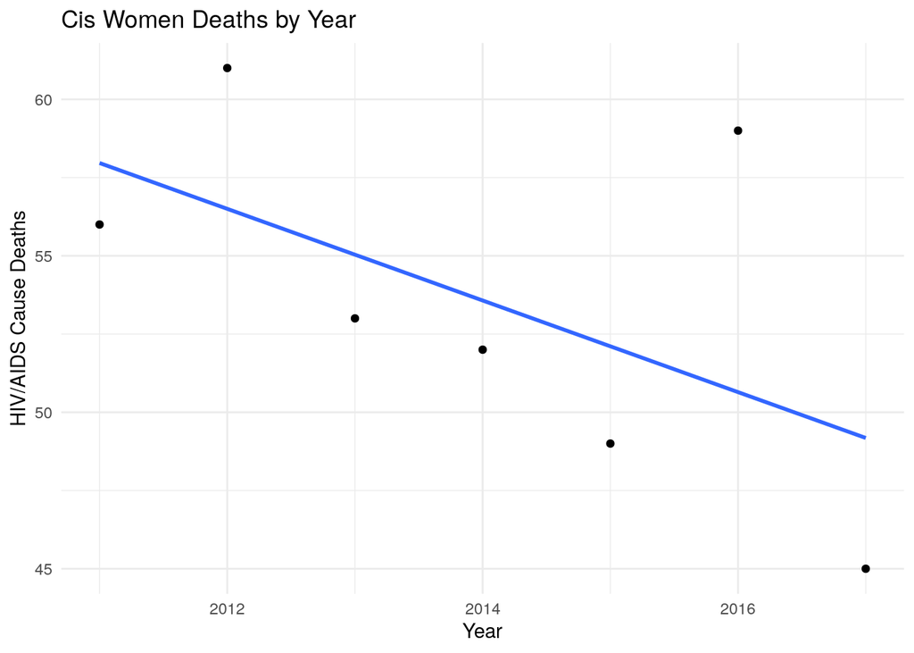

```r
ggplot(DF_ciswomen, aes(x = year, y = count)) +
  geom_point() +
  geom_smooth(method = "lm", se = FALSE)+
  labs(x = "Year",
       y= "HIV/AIDS Cause Deaths",
       title = "Cis Women Deaths by Year") +
  theme_minimal()
```

```r
myMod3 <- lm(count ~ year, data = DF_ciswomen)
summary(myMod3)
```

```
##
## Call:
## lm(formula = count ~ year, data = DF_ciswomen)
##
## Residuals:
##      1      2      3      4      5      6      7
## -1.964  4.500 -2.036 -1.571 -3.107  8.357 -4.179
##
## Coefficients:
##             Estimate Std. Error t value Pr(>|t|)
## (Intercept) 3002.643   1923.334   1.561    0.179
## year          -1.464      0.955  -1.533    0.186
##
## Residual standard error: 5.053 on 5 degrees of freedom
## Multiple R-squared:  0.3198, Adjusted R-squared:  0.1838
## F-statistic: 2.351 on 1 and 5 DF,  p-value: 0.1858
```

### Test #3

- Lastly, I wanted to consider which category, race, gender, age, or transmission method, is the best predictor of cause deaths by HIV/AIDS. The data I have selected however, does not lend itself to this nicely. Thus, I chose to analyze the relationship between race and cause deaths by HIV/AIDS.
- First, I created my new data frame.

```r
DF_race_ethnicity <- DF %>%
  group_by(race_ethnicity) %>%
  summarise(count = sum(count)) %>%
  arrange(desc(count)) %>%
  na.omit()

DF_race_ethnicity
```

```
## # A tibble: 7 × 2
##   race_ethnicity                   count
##   <fct>                            <dbl>
## 1 White                              973
## 2 Multiple races                     778
## 3 Latinx                             750
## 4 American Indian/Alaska Native      725
## 5 Black/African American             671
## 6 Asian*                             500
## 7 Native Hawaiian/Pacific Islander   224
```

- Then, I visualized this relationship…

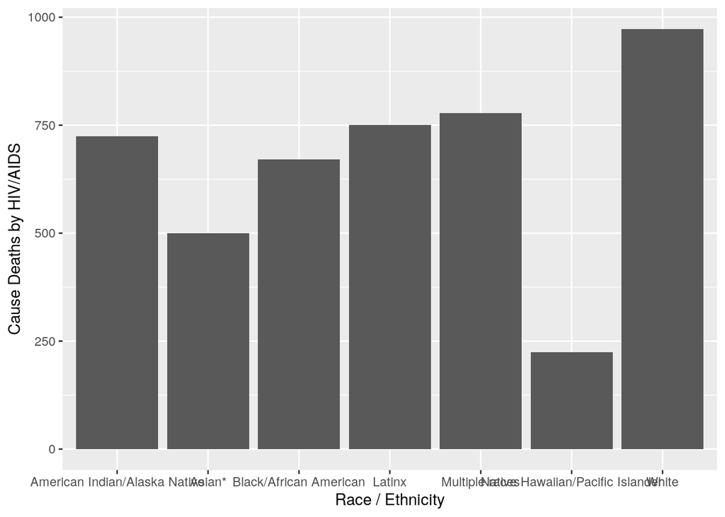

```r
ggplot(DF_race_ethnicity, aes(race_ethnicity, count))+
     geom_col()+
  labs(x = "Race / Ethnicity",
       y = "Cause Deaths by HIV/AIDS")
```

- Now, let’s run another tukey test to see if this is true…

```r
DF_model2 <- DF %>%
  slice(141:189)
myMod2 <- aov(count ~ race_ethnicity, data = DF_model2)
TukeyHSD(myMod2, conf.level=.95)
```

```
##   Tukey multiple comparisons of means
##     95% family-wise confidence level
##
## Fit: aov(formula = count ~ race_ethnicity, data = DF_model2)
##
## $race_ethnicity
##                                                                      diff
## Asian*-American Indian/Alaska Native                           -32.142857
## Black/African American-American Indian/Alaska Native            -7.714286
## Latinx-American Indian/Alaska Native                             3.571429
## Multiple races-American Indian/Alaska Native                     7.571429
## Native Hawaiian/Pacific Islander-American Indian/Alaska Native -71.571429
## White-American Indian/Alaska Native                             35.428571
## Black/African American-Asian*                                   24.428571
## Latinx-Asian*                                                   35.714286
## Multiple races-Asian*                                           39.714286
## Native Hawaiian/Pacific Islander-Asian*                        -39.428571
## White-Asian*                                                    67.571429
## Latinx-Black/African American                                   11.285714
## Multiple races-Black/African American                           15.285714
## Native Hawaiian/Pacific Islander-Black/African American        -63.857143
## White-Black/African American                                    43.142857
## Multiple races-Latinx                                            4.000000
## Native Hawaiian/Pacific Islander-Latinx                        -75.142857
## White-Latinx                                                    31.857143
## Native Hawaiian/Pacific Islander-Multiple races                -79.142857
## White-Multiple races                                            27.857143
## White-Native Hawaiian/Pacific Islander                         107.000000
##                                                                        lwr
## Asian*-American Indian/Alaska Native                            -83.314510
## Black/African American-American Indian/Alaska Native            -58.885939
## Latinx-American Indian/Alaska Native                            -47.600224
## Multiple races-American Indian/Alaska Native                    -43.600224
## Native Hawaiian/Pacific Islander-American Indian/Alaska Native -122.743081
## White-American Indian/Alaska Native                             -15.743081
## Black/African American-Asian*                                   -26.743081
## Latinx-Asian*                                                   -15.457367
## Multiple races-Asian*                                           -11.457367
## Native Hawaiian/Pacific Islander-Asian*                         -90.600224
## White-Asian*                                                     16.399776
```

[output cut: 39 more lines]

```
## Black/African American-Asian*                                  0.7560001
## Latinx-Asian*                                                  0.3380929
## Multiple races-Asian*                                          0.2230498
## Native Hawaiian/Pacific Islander-Asian*                        0.2302445
## White-Asian*                                                   0.0033746
## Latinx-Black/African American                                  0.9929000
## Multiple races-Black/African American                          0.9664027
## Native Hawaiian/Pacific Islander-Black/African American        0.0064800
## White-Black/African American                                   0.1489532
## Multiple races-Latinx                                          0.9999812
## Native Hawaiian/Pacific Islander-Latinx                        0.0008455
## White-Latinx                                                   0.4745736
## Native Hawaiian/Pacific Islander-Multiple races                0.0003976
## White-Multiple races                                           0.6292984
## White-Native Hawaiian/Pacific Islander                         0.0000017
```

- These results indicate the following conclusions:
  - Native Hawaiin/Pacific Islander people experience significantly **less** cause deaths by HIV/AIDS than those who are American Indian/Alaskan Native.
  - Native Hawaiian/Pacific Islander people experience significantly **less** cause deaths by HIV/AIDS than those who are Black/African American.
  - Native Hawaiian/Pacific Islander people experience significantly **less** cause deaths by HIV/AIDS than those who are Latinx.
  - Native Hawaiian/Pacific Islander people experience significantly **less** cause deaths by HIV/AIDS than those who are multiple races.
  - White people experience significantly **more** cause deaths by HIV/AIDS than those who are Asian.
  - White people experience significantly **more** cause deaths by HIV/AIDS than those who are Native Hawaiian/Pacific Islander.

## Challenges

- The main take away from this analysis is that gender is a key predictor for HIV/AIDS cause deaths and that trans and cis women are more likely to experience death due to HIV/AIDS.
- After completing this project, there is a few things I would do differently…
  - I would spend more time considering which data I would use. The data I found was pretty difficult to work with and didn’t contain as much information as I had hoped.
  - I would find data with a larger sample size over a greater amount of time.
    - Certain analyses could have been improved if my data spanned over more years.
  - I would conduct more tests if possible.

## References

Zena Sharman. (2016). The Remedy : Queer and Trans Voices on Health and Health Care. Arsenal Pulp Press.

Jennie Jacobs Kronenfeld. (2018). Gender, Women’s Health Care Concerns and Other Social Factors in Health and Health Care: Vol. First edition. Emerald Publishing Limited